# Assignment3

Cagdas Yetkin

February 11, 2018

## 1. PCA for supervised learning

### a. Do a short exploration of data and find possible predictors of `crim`

No missing values, very clean data.

```r
data <- data.table(Boston)

summary(data)
```

```
##       crim                zn             indus            chas
##  Min.   : 0.00632   Min.   :  0.00   Min.   : 0.46   Min.   :0.00000
##  1st Qu.: 0.08204   1st Qu.:  0.00   1st Qu.: 5.19   1st Qu.:0.00000
##  Median : 0.25651   Median :  0.00   Median : 9.69   Median :0.00000
##  Mean   : 3.61352   Mean   : 11.36   Mean   :11.14   Mean   :0.06917
##  3rd Qu.: 3.67708   3rd Qu.: 12.50   3rd Qu.:18.10   3rd Qu.:0.00000
##  Max.   :88.97620   Max.   :100.00   Max.   :27.74   Max.   :1.00000
##       nox               rm             age              dis
##  Min.   :0.3850   Min.   :3.561   Min.   :  2.90   Min.   : 1.130
##  1st Qu.:0.4490   1st Qu.:5.886   1st Qu.: 45.02   1st Qu.: 2.100
##  Median :0.5380   Median :6.208   Median : 77.50   Median : 3.207
##  Mean   :0.5547   Mean   :6.285   Mean   : 68.57   Mean   : 3.795
##  3rd Qu.:0.6240   3rd Qu.:6.623   3rd Qu.: 94.08   3rd Qu.: 5.188
##  Max.   :0.8710   Max.   :8.780   Max.   :100.00   Max.   :12.127
##       rad              tax           ptratio          black
##  Min.   : 1.000   Min.   :187.0   Min.   :12.60   Min.   :  0.32
##  1st Qu.: 4.000   1st Qu.:279.0   1st Qu.:17.40   1st Qu.:375.38
##  Median : 5.000   Median :330.0   Median :19.05   Median :391.44
##  Mean   : 9.549   Mean   :408.2   Mean   :18.46   Mean   :356.67
##  3rd Qu.:24.000   3rd Qu.:666.0   3rd Qu.:20.20   3rd Qu.:396.23
##  Max.   :24.000   Max.   :711.0   Max.   :22.00   Max.   :396.90
##      lstat            medv
##  Min.   : 1.73   Min.   : 5.00
##  1st Qu.: 6.95   1st Qu.:17.02
##  Median :11.36   Median :21.20
##  Mean   :12.65   Mean   :22.53
##  3rd Qu.:16.95   3rd Qu.:25.00
##  Max.   :37.97   Max.   :50.00
```

Explore some predictors

```r
glimpse(data)
```

```
## Observations: 506
## Variables: 14
## $ crim    <dbl> 0.00632, 0.02731, 0.02729, 0.03237, 0.06905, 0.02985, ...
## $ zn      <dbl> 18.0, 0.0, 0.0, 0.0, 0.0, 0.0, 12.5, 12.5, 12.5, 12.5,...
## $ indus   <dbl> 2.31, 7.07, 7.07, 2.18, 2.18, 2.18, 7.87, 7.87, 7.87, ...
## $ chas    <int> 0, 0, 0, 0, 0, 0, 0, 0, 0, 0, 0, 0, 0, 0, 0, 0, 0, 0, ...
## $ nox     <dbl> 0.538, 0.469, 0.469, 0.458, 0.458, 0.458, 0.524, 0.524...
## $ rm      <dbl> 6.575, 6.421, 7.185, 6.998, 7.147, 6.430, 6.012, 6.172...
## $ age     <dbl> 65.2, 78.9, 61.1, 45.8, 54.2, 58.7, 66.6, 96.1, 100.0,...
## $ dis     <dbl> 4.0900, 4.9671, 4.9671, 6.0622, 6.0622, 6.0622, 5.5605...
## $ rad     <int> 1, 2, 2, 3, 3, 3, 5, 5, 5, 5, 5, 5, 5, 4, 4, 4, 4, 4, ...
## $ tax     <dbl> 296, 242, 242, 222, 222, 222, 311, 311, 311, 311, 311,...
## $ ptratio <dbl> 15.3, 17.8, 17.8, 18.7, 18.7, 18.7, 15.2, 15.2, 15.2, ...
## $ black   <dbl> 396.90, 396.90, 392.83, 394.63, 396.90, 394.12, 395.60...
## $ lstat   <dbl> 4.98, 9.14, 4.03, 2.94, 5.33, 5.21, 12.43, 19.15, 29.9...
## $ medv    <dbl> 24.0, 21.6, 34.7, 33.4, 36.2, 28.7, 22.9, 27.1, 16.5, ...
```

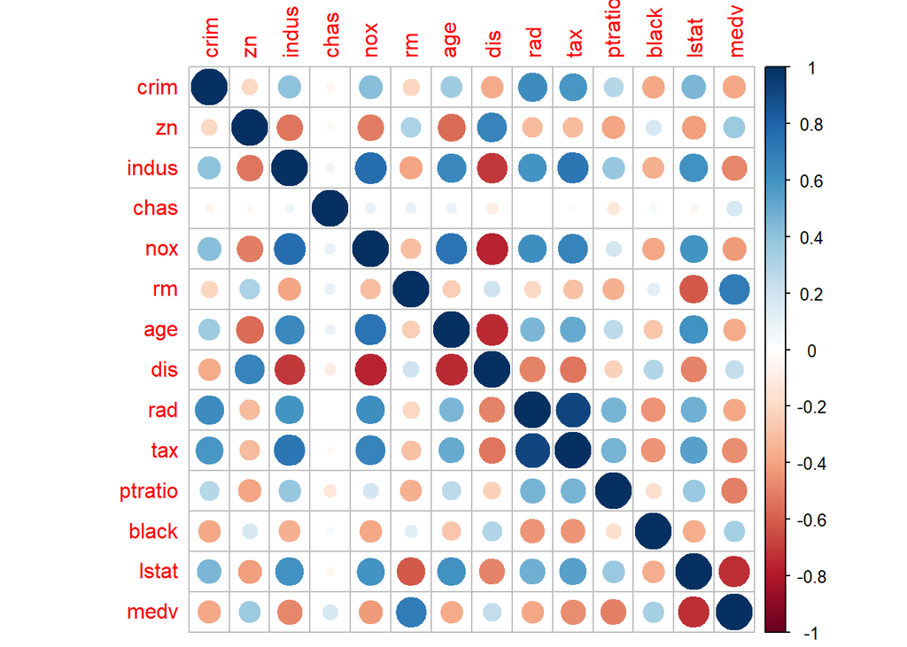

```r
M <- cor(data)
corrplot(M, method = "circle")
```

Crime is strongly positive corralated with rad and tax. And a bit negatively with Black and Medv. Charles River is actually a boolean.

### b. Create a training and a test set of 50%

```r
set.seed(1234)
training_ratio <- 0.5
train_indices <- createDataPartition(y = data[["crim"]],
                                     times = 1,
                                     p = training_ratio,
                                     list = FALSE)
data_train <- data[train_indices, ]
data_test <- data[-train_indices, ]
```

### c. Use a linear regression to predict `crim` and use 10-fold cross validation

```r
train_control <- trainControl(method = "cv",
                              number = 10)
set.seed(93)
lm_fit <- train(crim ~ .,
                   method = "lm",
                   data = data_train,
                   trControl = train_control)

mean(data.table(lm_fit$results["RMSE"])$RMSE)
```

```
## [1] 6.002655
```

### d. Try to improve the model by using PCA for dimensionality reduction

**Center and scale your variables and use pcr to conduct a search for the optimal number of principal components. Does PCA improve the fit over the simple linear model?**

PCR gave a very closed result to linear one

```r
tune_grid <- data.frame(ncomp = 1:13)

set.seed(93)
pcr_fit <- train(crim ~ . ,
                data = data_train,
                method = "pcr",
                trControl = train_control,
                tuneGrid = tune_grid,
                preProcess = c("center", "scale"))
pcr_fit
```

```
## Principal Component Analysis
##
## 254 samples
##  13 predictor
##
## Pre-processing: centered (13), scaled (13)
## Resampling: Cross-Validated (10 fold)
## Summary of sample sizes: 227, 228, 229, 229, 228, 229, ...
## Resampling results across tuning parameters:
##
##   ncomp  RMSE      Rsquared   MAE
##    1     6.653168  0.4868609  3.929938
##    2     6.652953  0.4900252  3.963360
##    3     6.212899  0.5916002  3.252496
##    4     6.183134  0.5929469  3.204149
##    5     6.191486  0.5917444  3.225706
##    6     6.117584  0.5979798  3.276409
##    7     6.145949  0.5968942  3.310422
##    8     5.998864  0.6191313  3.174759
##    9     6.076978  0.6084398  3.212837
##   10     6.110247  0.6039979  3.168346
##   11     6.097178  0.6103361  3.172619
##   12     6.058882  0.6305097  3.251860
##   13     6.002655  0.6384234  3.179640
##
## RMSE was used to select the optimal model using the smallest value.
## The final value used for the model was ncomp = 8.
```

### e. Use penalized linear models for the same task

**Make sure to include ridge (alpha = 0) to your tune grid. How does the best model compare to that found in d)? Would pre-processing via PCA help this model? (add pca to preProcess). Why do you think the answer can be expected?**

Ridge performed better. I would prefer ridge method here.

Considering that we are not dealing with a big sample size and number of variables, maybe pca isnt necessary.

```r
tune_grid = expand.grid(
              .alpha=0,
              .lambda=seq(0, 2, by = 0.01))

set.seed(123)
ridge_fit <- train(crim ~ .,
                   method = "glmnet",
                   data = data_train,
                   trControl = train_control,
                   tuneGrid = tune_grid,
                   preProcess = c("center", "scale"))

mean(data.table(ridge_fit$results["RMSE"])$RMSE)
```

```
## [1] 5.827851
```

```r
set.seed(123)
ridge_pca_fit <- train(crim ~ .,
                     method = "glmnet",
                     data = data_train,
                     trControl = train_control,
                     tuneGrid = tune_grid,
                     preProcess = c("center", "scale", "pca"))

mean(data.table(ridge_pca_fit$results["RMSE"])$RMSE)
```

```
## [1] 5.880555
```

### f. Evaluate your preferred model on the test set

Ridge is performing fairly on the test set also

```r
test_prediction <- predict(ridge_fit, newdata = data_test)
RMSE(test_prediction, data_test[["crim"]])
```

```
## [1] 6.139376
```

```r
RMSE(test_prediction, data_test$crim)
```

```
## [1] 6.139376
```

## 2. Clustering on the `USArrests` datase [week4]

```r
cat("\f")
```

```r
rm(list=ls())
data <- USArrests
summary(data)
```

```
##      Murder          Assault         UrbanPop          Rape
##  Min.   : 0.800   Min.   : 45.0   Min.   :32.00   Min.   : 7.30
##  1st Qu.: 4.075   1st Qu.:109.0   1st Qu.:54.50   1st Qu.:15.07
##  Median : 7.250   Median :159.0   Median :66.00   Median :20.10
##  Mean   : 7.788   Mean   :170.8   Mean   :65.54   Mean   :21.23
##  3rd Qu.:11.250   3rd Qu.:249.0   3rd Qu.:77.75   3rd Qu.:26.18
##  Max.   :17.400   Max.   :337.0   Max.   :91.00   Max.   :46.00
```

### a. Determine the optimal number of clusters

`NbClust` results with an optimal number of 2 clusters!

```r
nb <- NbClust(data, method = "kmeans",
              min.nc = 2, max.nc = 10, index = "all")
```

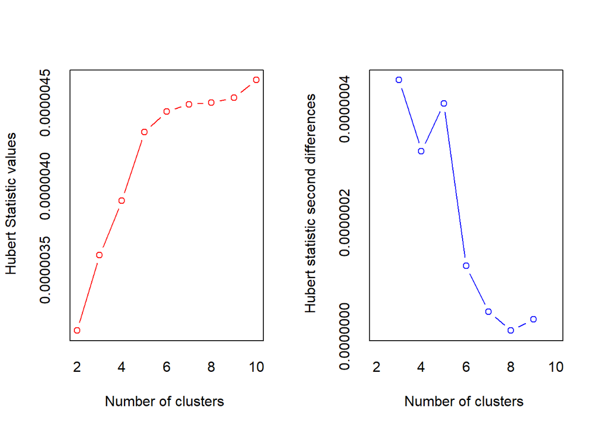

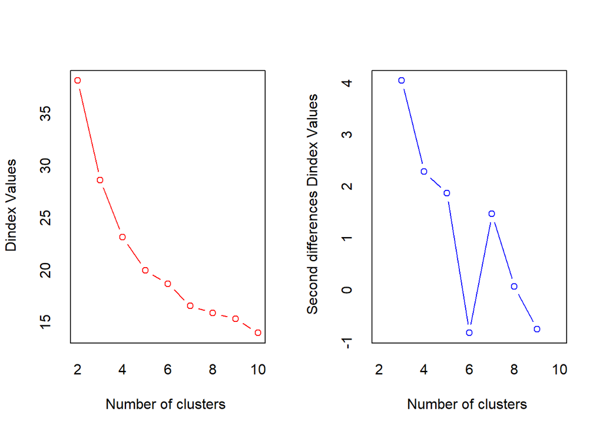

### b. Use the k-means method to cluster states. Plot observations

2 clusters look good!

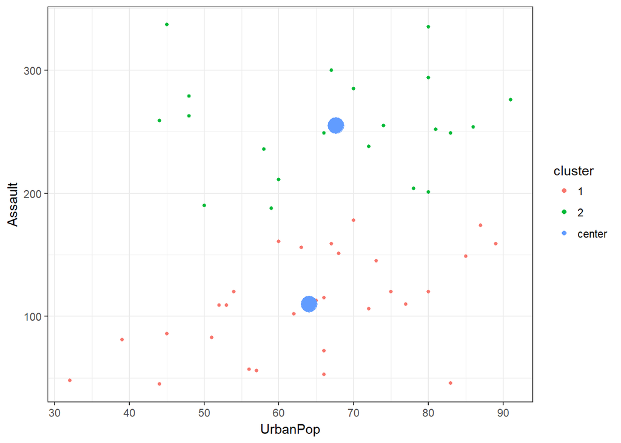

```r
set.seed(1234)
km <- kmeans(data, centers = 2, nstart = 50)

data_clusters <- cbind(data, data.table("cluster" = factor(km$cluster)))

centers_2 <- data.table(km$centers)
centers_2[, cluster := factor("center", levels = c(1, 2, "center"))]


data_clusters <- rbind(data_clusters, centers_2)


ggplot(data_clusters, aes(x = UrbanPop, y = Assault, color = cluster,
           size = ifelse(cluster == "center", 2, 1))) +
            geom_point() +
            scale_size(guide = 'none')
```

### c. Perform PCA and get the first two principal component coordinates for all observations

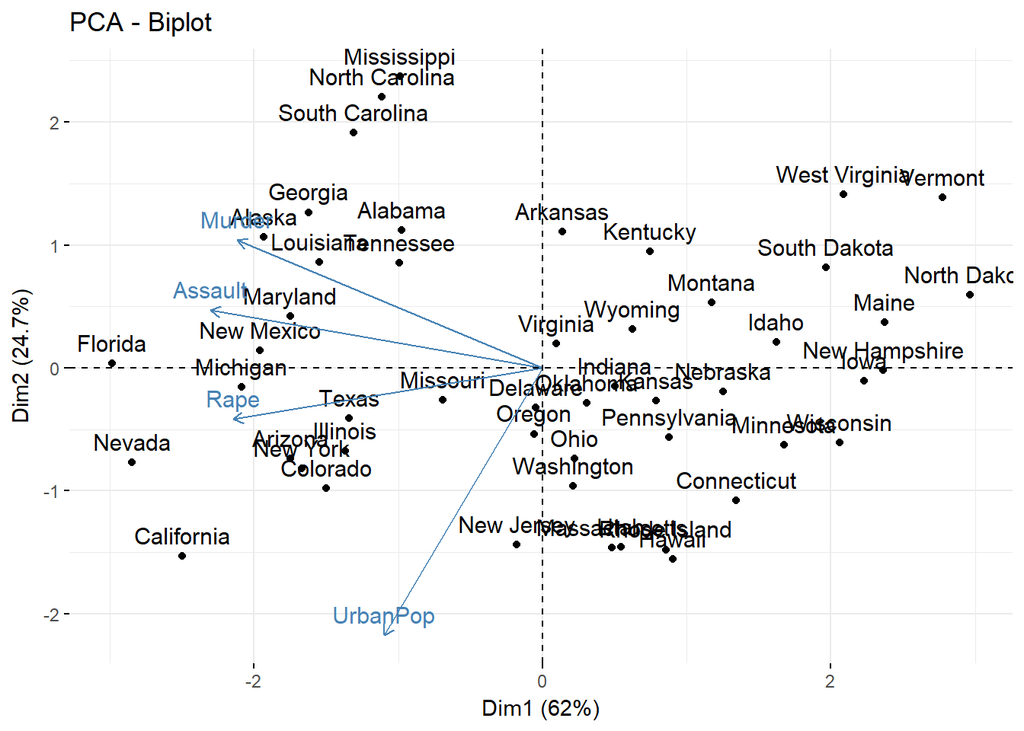

```r
pca_result <- prcomp(data, scale. = TRUE)

first_two_pc <- data.table(pca_result$x[, 1:2])
fviz_pca(pca_result)
```

```r
data_clusters_pca <- cbind(data_clusters, first_two_pc)
```

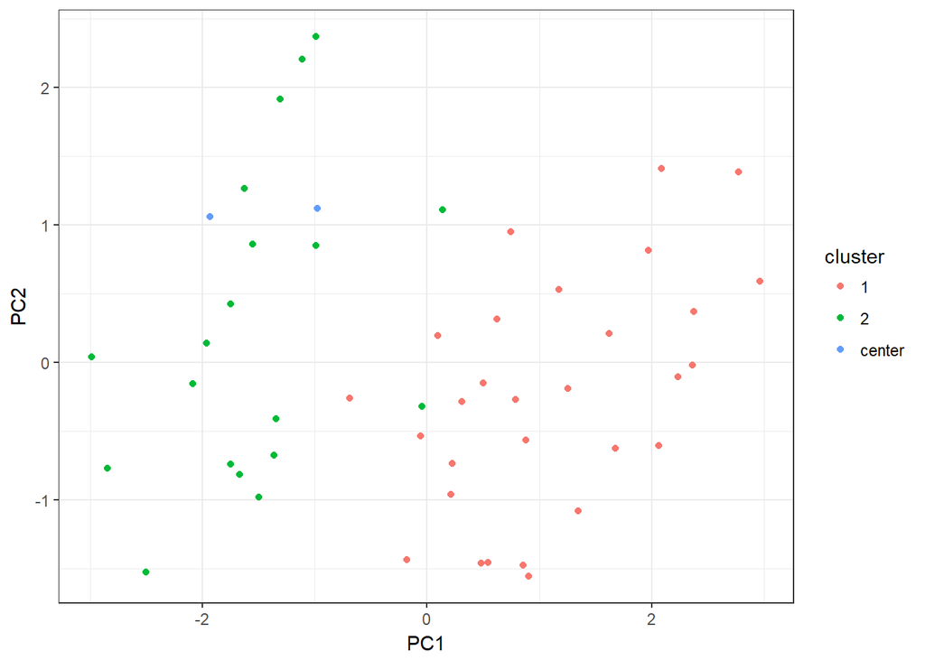

```r
ggplot(data_clusters_pca, aes(x = PC1, y = PC2, color = cluster)) + geom_point() + scale_size(guide = 'none')
```

## 3. PCA of high-dimensional data

```r
rm(list=ls())

data <- fread("./gene_data.csv")
data$is_diseased
```

```
##  [1] "healthy"  "healthy"  "healthy"  "healthy"  "healthy"  "healthy"
##  [7] "healthy"  "healthy"  "healthy"  "healthy"  "healthy"  "healthy"
## [13] "healthy"  "healthy"  "healthy"  "healthy"  "healthy"  "healthy"
## [19] "healthy"  "healthy"  "diseased" "diseased" "diseased" "diseased"
## [25] "diseased" "diseased" "diseased" "diseased" "diseased" "diseased"
## [31] "diseased" "diseased" "diseased" "diseased" "diseased" "diseased"
## [37] "diseased" "diseased" "diseased" "diseased"
```

```r
data[, is_diseased := factor(is_diseased)]
dim(data)
```

```
## [1]   40 1001
```

```r
tail(names(data))
```

```
## [1] "measure_995" "measure_996" "measure_997" "measure_998" "measure_999"
## [6] "is_diseased"
```

### a. Perform PCA with scaling features

Amazing! 40 PC can capture the all variation. Considering the original 1000 variables, this is a significant result in dimension reduction.

```r
data_features <- copy(data)
data_features[, is_diseased := NULL]

pca_result <- prcomp(data_features, scale. = TRUE)
summary(pca_result)
```

```
## Importance of components:
##                            PC1     PC2     PC3     PC4     PC5     PC6
## Standard deviation     9.00460 5.87302 5.74347 5.61806 5.55344 5.50107
## Proportion of Variance 0.08108 0.03449 0.03299 0.03156 0.03084 0.03026
## Cumulative Proportion  0.08108 0.11558 0.14856 0.18013 0.21097 0.24123
##                            PC7     PC8    PC9    PC10    PC11    PC12
## Standard deviation     5.40069 5.38575 5.3762 5.34146 5.31878 5.25016
## Proportion of Variance 0.02917 0.02901 0.0289 0.02853 0.02829 0.02756
## Cumulative Proportion  0.27040 0.29940 0.3283 0.35684 0.38513 0.41269
##                           PC13   PC14    PC15    PC16    PC17    PC18
## Standard deviation     5.18737 5.1667 5.10384 5.04667 5.03288 4.98926
## Proportion of Variance 0.02691 0.0267 0.02605 0.02547 0.02533 0.02489
## Cumulative Proportion  0.43960 0.4663 0.49234 0.51781 0.54314 0.56803
##                           PC19    PC20    PC21    PC22    PC23    PC24
## Standard deviation     4.92635 4.90996 4.88803 4.85159 4.79974 4.78202
## Proportion of Variance 0.02427 0.02411 0.02389 0.02354 0.02304 0.02287
## Cumulative Proportion  0.59230 0.61641 0.64030 0.66384 0.68688 0.70975
##                           PC25    PC26    PC27    PC28    PC29    PC30
## Standard deviation     4.70171 4.66105 4.64595 4.59194 4.53246 4.47381
## Proportion of Variance 0.02211 0.02173 0.02158 0.02109 0.02054 0.02001
## Cumulative Proportion  0.73185 0.75358 0.77516 0.79625 0.81679 0.83681
##                          PC31    PC32    PC33   PC34    PC35   PC36
## Standard deviation     4.4389 4.41670 4.39404 4.3591 4.23504 4.2184
## Proportion of Variance 0.0197 0.01951 0.01931 0.0190 0.01794 0.0178
## Cumulative Proportion  0.8565 0.87602 0.89533 0.9143 0.93226 0.9501
##                           PC37   PC38    PC39      PC40
## Standard deviation     4.12936 4.0738 4.03658 5.655e-15
## Proportion of Variance 0.01705 0.0166 0.01629 0.000e+00
## Cumulative Proportion  0.96711 0.9837 1.00000 1.000e+00
```

### b. Visualize datapoints in the space of the first two principal components

First 20 healthy and the last 20 were disesased in our data. We can see this separation by 1st principal component in the plot.

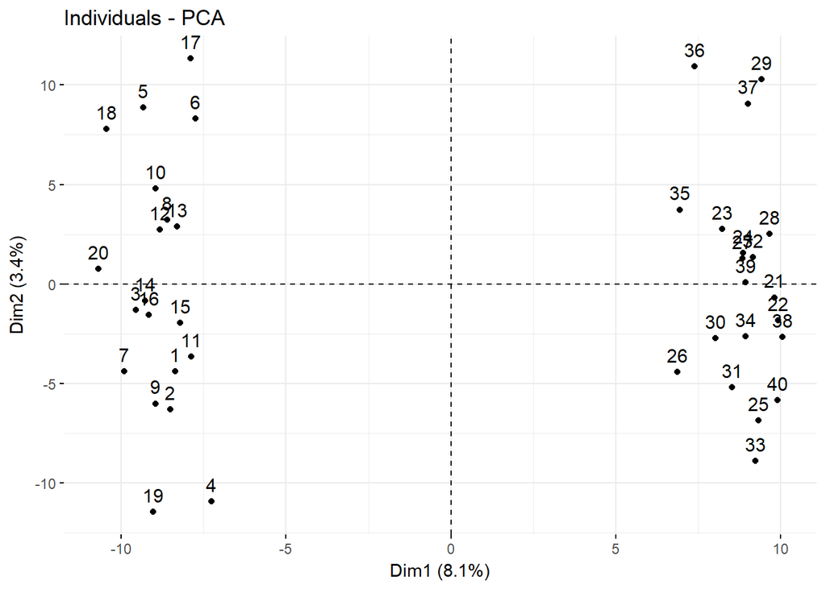

```r
fviz_pca_ind(pca_result)
```

### c. Which individual features can matter the most in separating diseased from healthy?

**Choose the two features with the largest coordinates and plot observations in the coordinate system defined by these two original features. What do you see?**

First of all, in the plot the cluster around 500 is nicely capturing the most important individual features. (502 and 589) separating healty from sick. Their correlation score is also significant.

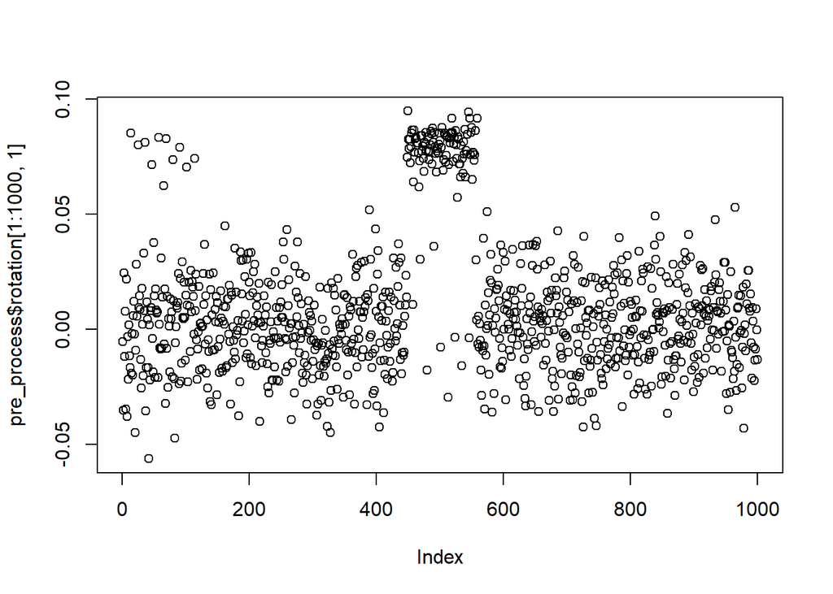

```r
pre_process <- preProcess(data_features, method = c("center", "scale", "pca"))
plot(pre_process$rotation[1:1000,1])
```

```r
x <- pca_result$rotation[,1]
x[order(x, decreasing = TRUE)][1:2]
```

```
## measure_502 measure_589
##  0.09485044  0.09449766
```

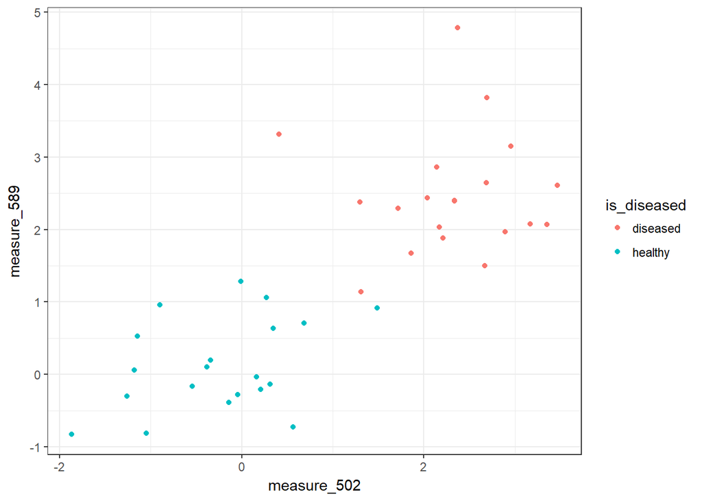

```r
ggplot(data, aes(x = measure_502, y = measure_589, color = is_diseased)) + geom_point()
```

```r
#go ahead for the correlation
cor(data_features$measure_502, data_features$measure_589)
```

```
## [1] 0.7803975
```